# Wearable Computing: Classification of Body Postures and Movements (PUC-Rio) Data Set

Oliver Kocsis

February 23, 2016

This machine learning project uses the a dataset of a research on Human Activity Recognition (HAR): [Wearable Computing: Classification of Body Postures and Movements (PUC-Rio) Data Set](http://archive.ics.uci.edu/ml/datasets/Wearable+Computing%3A+Classification+of+Body+Postures+and+Movements+%28PUC-Rio%29).

The dataset contains 5 activity classes (sitting-down, standing-up, standing, walking, and sitting), collected from 4 healthy subjects wearing accelerometers during 8 hours of activities. The sensors were mounted on their waist, left thigh, right arm, and right ankle. The classification uses 12 (x, y, z coordinates of 4 accelerometers) input attributes derived from a time window of 150ms.

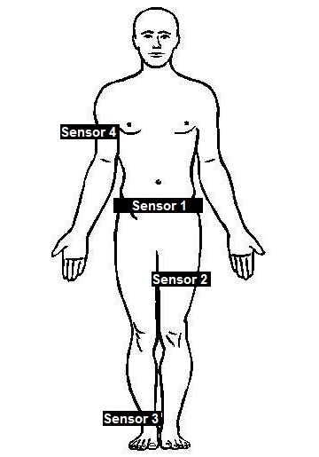

The original research used AdaBoost that combines ten Decision Trees. Their observed classifier accuracy was 99.4%. This project compares the accuracy of 4 models (Distributed Random Forest, Gradient Boosting Method, Neural Networks, and Deep Learning). The model parameters are evaluated via grid search.

# Exploratory Data Analyisis

The original data set is a well formatted coma separated file which does not requires extensive cleaning nor transformation. Though the 4th column was rename from “how_tall_in_meters” to “height”. There was only one N/A variable from the 4th sensor on the z coordinate so that observation was removed from the dataset.

```r
library(data.table)
library(knitr)
seed <- 2016
set.seed(2016)

data <- read.csv("dataset-har-PUC-Rio-ugulino.csv", sep = ";", stringsAsFactors = FALSE)
setDT(data)
colnames(data)[4] <- "height"
data[, gender := as.factor(gender)]
data[, age := as.integer(age)]
data[, height := as.numeric(gsub(",", ".", height))]
data[, weight := as.integer(weight)]
data[, body_mass_index := as.numeric(gsub(",", ".", body_mass_index))]
data[, x1 := as.integer(x1)]
data[, y1 := as.integer(y1)]
data[, z1 := as.integer(z1)]
data[, x2 := as.integer(x2)]
data[, y2 := as.integer(y2)]
data[, z2 := as.integer(z2)]
data[, x3 := as.integer(y3)]
data[, y3 := as.integer(x3)]
data[, z3 := as.integer(z3)]
data[, x4 := as.integer(x4)]
data[, y4 := as.integer(y4)]
data[, z4 := as.integer(z4)]
data[, class := factor(class)]
data <- data[!is.na(z4)]
```

## Classes

The dataset contains 5 activity classes (sitting-down, standing-up, standing, walking, and sitting). They vary in number of observations related to them.

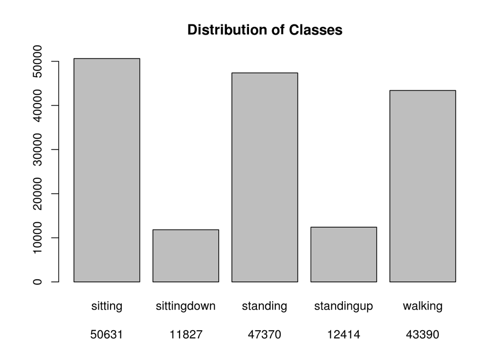

```r
barplot.with.values <- function(values, names.arg, main) {
  names(values) <- names.arg
  bp <- barplot(values, main = main)
  mtext(side = 1, at = bp, text = values, line = 3)
}
class <- data[, .N, by = class]
setkey(class, class)
par(mfrow=c(1,1))
barplot.with.values(class$N, class$class, "Distribution of Classes")
```

## Subjects

The dataset is recorder from 4 healthy subjects (Debora, Jose Carlos, Katia, Wallace). They vary in height, weight, age and number of observations.

```r
user <- data[,.(Gender = max(gender),
                Age = max(age),
                Height = max(height),
                Weight = max(weight),
                BMI = max(body_mass_index),
                N = .N),
             by = user]
setkey(user, user)
kable(user)
```

| user | Gender | Age | Height | Weight | BMI | N |
| --- | --- | --- | --- | --- | --- | --- |
| debora | Woman | 46 | 1.62 | 75 | 28.6 | 51577 |
| jose_carlos | Man | 75 | 1.67 | 67 | 24.0 | 13160 |
| katia | Woman | 28 | 1.58 | 55 | 22.0 | 49797 |
| wallace | Man | 31 | 1.71 | 83 | 28.4 | 51098 |

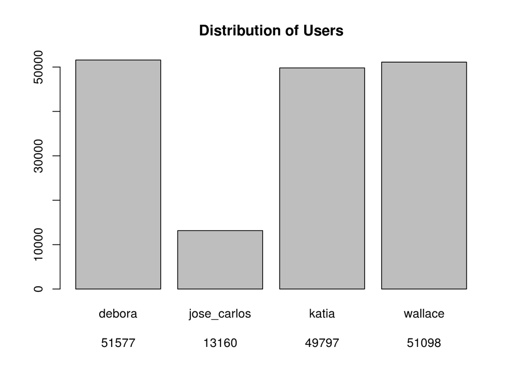

```r
par(mfrow=c(1,1))
barplot.with.values(user$N, user$user, "Distribution of Users")
```

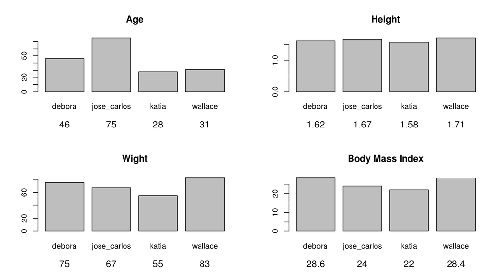

```r
par(mfrow=c(2,2))
barplot.with.values(user$Age, user$user, "Age")
barplot.with.values(user$Height, user$user, "Height")
barplot.with.values(user$Weight, user$user, "Wight")
barplot.with.values(user$BMI, user$user, "Body Mass Index")
```

## Sensors

There are 12 input attributes in total derived from a time window of 150ms. The attributes are the x, y, z coordinates of 4 accelerometers.

The variance of the sensor values vary during different activity classes. This difference is visible which makes the machine learning promising for classification.

```r
boxplot.sensor <- function(sensor, title) {
  par(mfrow=c(1,5))
  for (c in class$class) {
    boxplot(value ~ variable, data = sensor[class == c], ylim = c(-300,300), main = c)
  }
  title(title, outer=TRUE)
  par(mfrow=c(1,1))
}
sensor_1 <- melt(data, id.vars = c("user", "class"), measure.vars = c("x1", "y1", "z1"))
sensor_2 <- melt(data, id.vars = c("user", "class"), measure.vars = c("x2", "y2", "z2"))
sensor_3 <- melt(data, id.vars = c("user", "class"), measure.vars = c("x3", "y3", "z3"))
sensor_4 <- melt(data, id.vars = c("user", "class"), measure.vars = c("x4", "y4", "z4"))
```

### Sensor 1 Waist

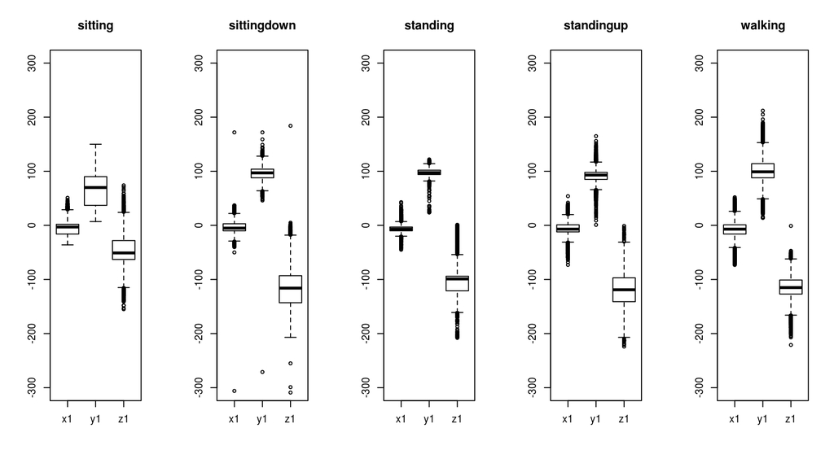

```r
boxplot.sensor(sensor_1, NULL)
```

### Sensor 2 Left Thigh

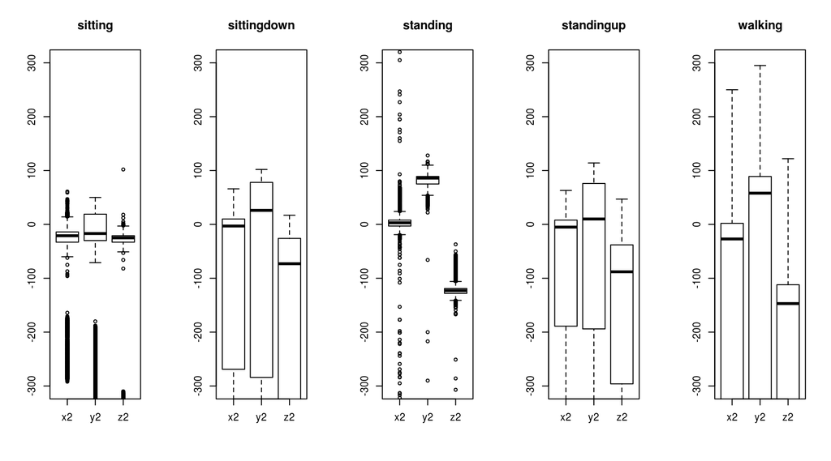

```r
boxplot.sensor(sensor_2, NULL)
```

### Sensor 3 Right Ankle

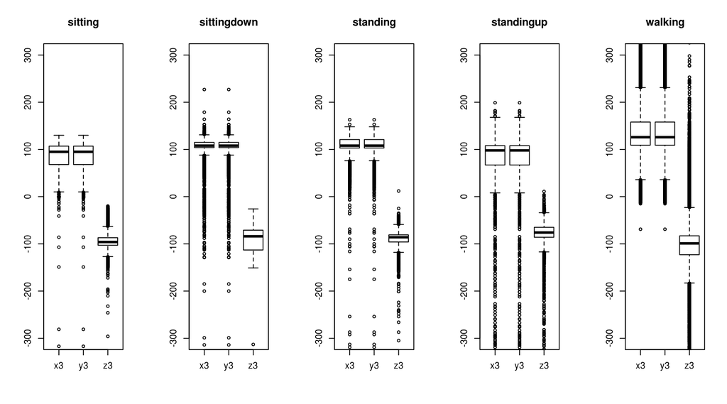

```r
boxplot.sensor(sensor_3, NULL)
```

### Sensor 4 Right Arm

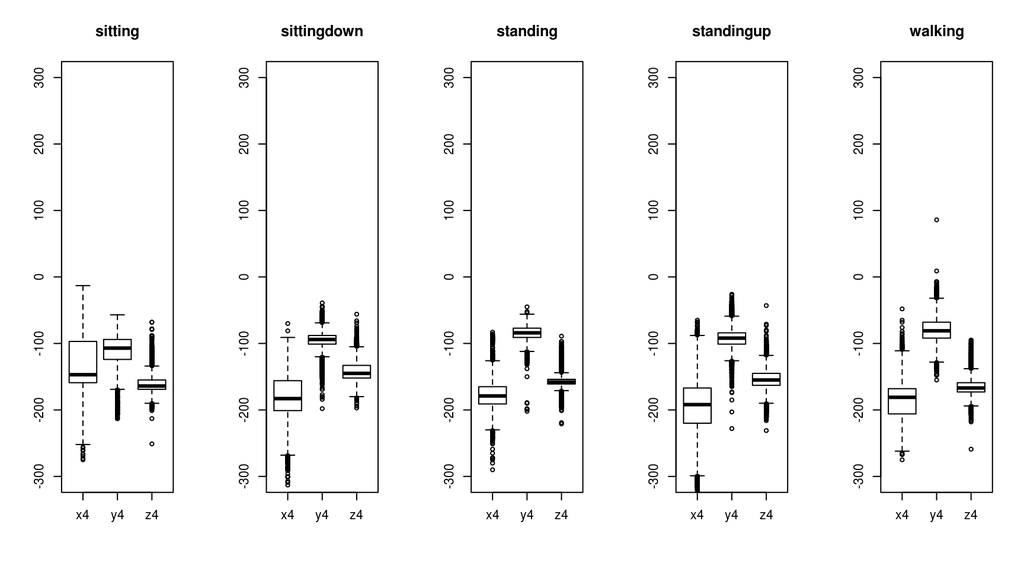

```r
boxplot.sensor(sensor_4, NULL)
```

### 3D

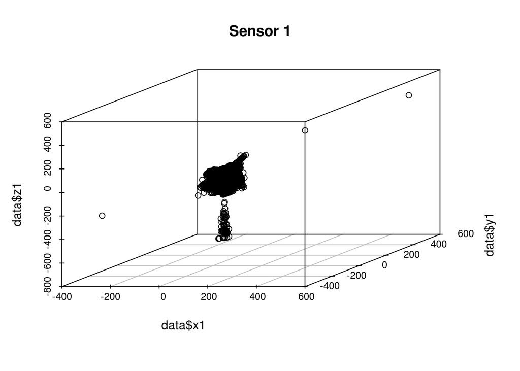

```r
library(scatterplot3d)
par(mfrow=c(1,1))
scatterplot3d(data$x1, data$y1, data$z1, main="Sensor 1")
```

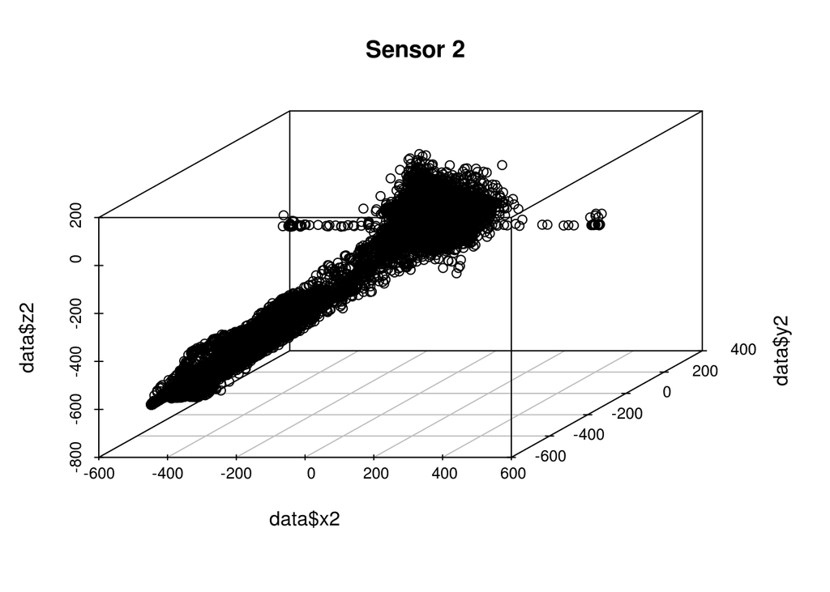

```r
scatterplot3d(data$x2, data$y2, data$z2, main="Sensor 2")
```

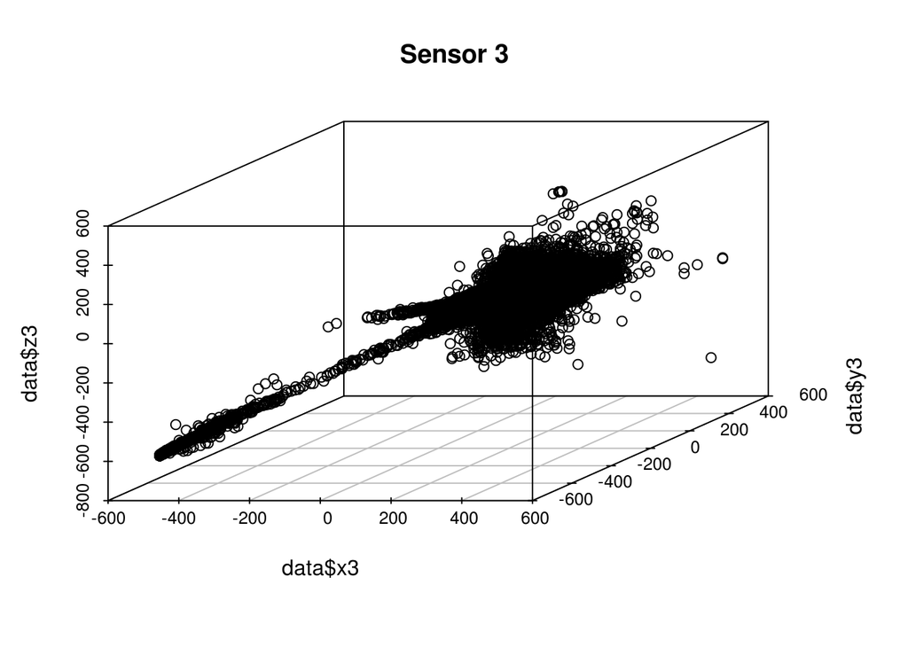

```r
scatterplot3d(data$x3, data$y3, data$z3, main="Sensor 3")
```

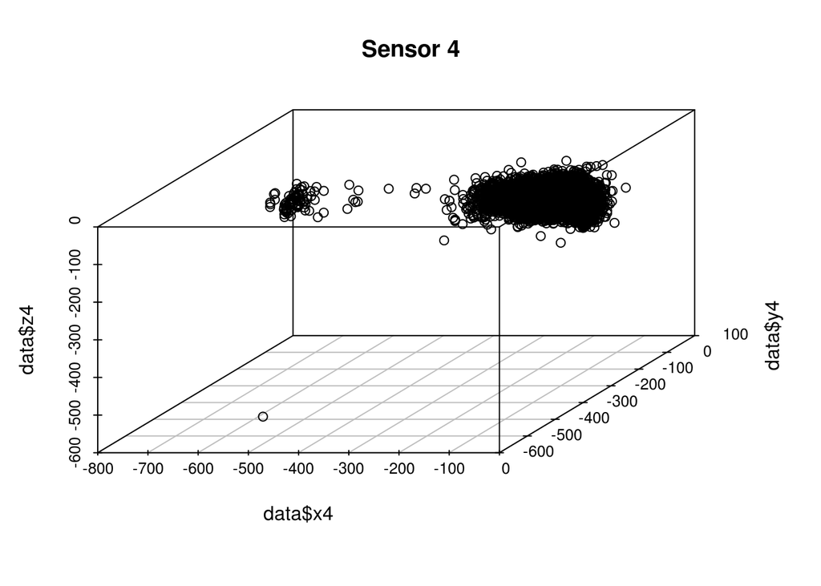

```r
scatterplot3d(data$x4, data$y4, data$z4, main="Sensor 4")
```

# Supervised Learning Methods

The original dataset contains 165K observations. This data set is divide into train, test and validations sets.

```r
#### Training, Validation, and Test sets ####
N <- nrow(data)
idx_train <- sample(1:N,N/2)
idx_valid <- sample(base::setdiff(1:N, idx_train), N/4)
idx_test <- base::setdiff(base::setdiff(1:N, idx_train),idx_valid)
d_train <- data[idx_train,]
d_valid <- data[idx_valid,]
d_test  <- data[idx_test,]
```

## Mini Batch

Due to long execution of supervised learning methods (around 1 hour per model) using the original dataset, a random mini batch is selected with 20K observations. This mini batch is used for parameter selection via grid search. The method with the selected parameters is executed using the original dataset, so that the different methods can be compared.

```r
#### Mini batch for grid search ####
minibatch <- data[sample(1:N, 20000)]
N <- nrow(minibatch)
idx_train <- sample(1:N, 10000)
idx_valid <- sample(base::setdiff(1:N, idx_train), 5000)
idx_test <- base::setdiff(base::setdiff(1:N, idx_train),idx_valid)
mini_train <- minibatch[idx_train,]
mini_valid <- minibatch[idx_valid,]
mini_test  <- minibatch[idx_test,]
rm(N, idx_train, idx_valid, idx_test)
```

## H20

[H2O](http://www.h2o.ai/) is used as machine learning platform.

```r
library(h2o)
```

```r
h2o.init(max_mem_size = "4g", nthreads = -1)   ## starts Java server (R connects via REST)
```

```
##  Connection successful!
##
## R is connected to the H2O cluster:
##     H2O cluster uptime:         1 days 15 hours
##     H2O cluster version:        3.8.0.6
##     H2O cluster name:           H2O_started_from_R_oliver_onj626
##     H2O cluster total nodes:    1
##     H2O cluster total memory:   3.23 GB
##     H2O cluster total cores:    4
##     H2O cluster allowed cores:  4
##     H2O cluster healthy:        TRUE
##     H2O Connection ip:          localhost
##     H2O Connection port:        54321
##     H2O Connection proxy:       NA
##     R Version:                  R version 3.2.3 (2015-12-10)
```

```r
# h2o.removeAll() # Clean slate - just in case the cluster was already running
```

```r
dx_train <- as.h2o(d_train, "train")
dx_valid <- as.h2o(d_valid, "valid")
dx_test <- as.h2o(d_test, "test")

dm_train <- as.h2o(mini_train, "mini_train")
dm_valid <- as.h2o(mini_valid, "mini_valid")
dm_test <- as.h2o(mini_test, "mini_test")

d_x_idxs = 8:ncol(dx_train) - 1
d_y_idxs = ncol(dx_train)

grid.search <- function(algorithm, grid_id, hyper_params = list()){
  grid <- h2o.grid(algorithm, grid_id = grid_id, x = d_x_idxs, y = d_y_idxs,
                  training_frame = dm_train, validation_frame = dm_valid,
                  hyper_params = hyper_params,
                  stopping_rounds = 5, stopping_tolerance = 1e-3, seed = seed)
}

summarize.grid <- function(grid) {
  print(kable(grid@summary_table))
}

summarize.model <- function(model) {
  params <- data.table(h2o.r2(model, valid = TRUE), h2o.mse(model, valid = TRUE))
  colnames(params) <- c("R Squared", "Mean Squared Error")
  print(kable(params))

  print(kable(h2o.confusionMatrix(model, valid = TRUE)))

  try(varimp <- h2o.varimp(model), silent = TRUE)
  if(exists("varimp") & !is.null(varimp)) {
    print(kable(varimp))
  }
}

get.metrics <- function(name, model) {
  r2 <- h2o.r2(model, valid = TRUE)
  mse <- h2o.mse(model, valid = TRUE)
  logloss <- h2o.logloss(model, valid = TRUE)
  list(name = name, r2 = r2, mse = mse, logloss = logloss)
}
```

## Distributed Random Forest (Grid Search)

The default values of the Distributed Random Forest model are

- Number of trees (ntrees): 50
- Maximum tree depth (max_depth): 20
- For numerical columns - real/int -, build a histogram of - at least - this many bins, then split at the best point (nbins): 20

Grid search is used to find the best parameter in order to find the best parameter.

### Number of trees

```r
drf_ntrees <- grid.search("drf", grid_id = "drf_ntrees", hyper_params = list(ntrees = c(25, 50, 100, 200, 300, 400, 500)))
```

```r
summarize.grid(drf_ntrees)
```

| ntrees | model_ids | logloss |
| --- | --- | --- |
| 200 | drf_ntrees_model_3 | 0.0913282623259382 |
| 400 | drf_ntrees_model_5 | 0.0913925978874253 |
| 300 | drf_ntrees_model_4 | 0.0915251601143698 |
| 500 | drf_ntrees_model_6 | 0.0915496611795318 |
| 100 | drf_ntrees_model_2 | 0.0919106483584133 |
| 25 | drf_ntrees_model_0 | 0.0965703361907768 |
| 50 | drf_ntrees_model_1 | 0.0969942297454333 |

```r
best <- h2o.getModel(drf_ntrees@model_ids[[1]])
summarize.model(best)
```

| R Squared | Mean Squared Error |
| --- | --- |
| 0.9903355 | 0.0231472 |

|  | sitting | sittingdown | standing | standingup | walking | Error | Rate |
| --- | --- | --- | --- | --- | --- | --- | --- |
| sitting | 1516 | 0 | 0 | 1 | 0 | 0.0006592 | 1 / 1,517 |
| sittingdown | 6 | 357 | 3 | 5 | 6 | 0.0530504 | 20 / 377 |
| standing | 0 | 1 | 1410 | 3 | 1 | 0.0035336 | 5 / 1,415 |
| standingup | 6 | 12 | 12 | 365 | 4 | 0.0852130 | 34 / 399 |
| walking | 0 | 3 | 11 | 3 | 1275 | 0.0131579 | 17 / 1,292 |
| Totals | 1528 | 373 | 1436 | 377 | 1286 | 0.0154000 | 77 / 5,000 |

| variable | relative_importance | scaled_importance | percentage |
| --- | --- | --- | --- |
| z1 | 162847.75 | 1.0000000 | 0.1480087 |
| z2 | 154510.95 | 0.9488062 | 0.1404316 |
| y2 | 149199.58 | 0.9161906 | 0.1356042 |
| x3 | 96044.91 | 0.5897834 | 0.0872931 |
| y3 | 95311.55 | 0.5852801 | 0.0866265 |
| x4 | 83642.41 | 0.5136234 | 0.0760207 |
| y1 | 80719.68 | 0.4956757 | 0.0733643 |
| x2 | 78886.07 | 0.4844161 | 0.0716978 |
| z4 | 59958.22 | 0.3681857 | 0.0544947 |
| y4 | 55667.25 | 0.3418362 | 0.0505947 |
| z3 | 51245.60 | 0.3146841 | 0.0465760 |
| x1 | 32224.12 | 0.1978788 | 0.0292878 |

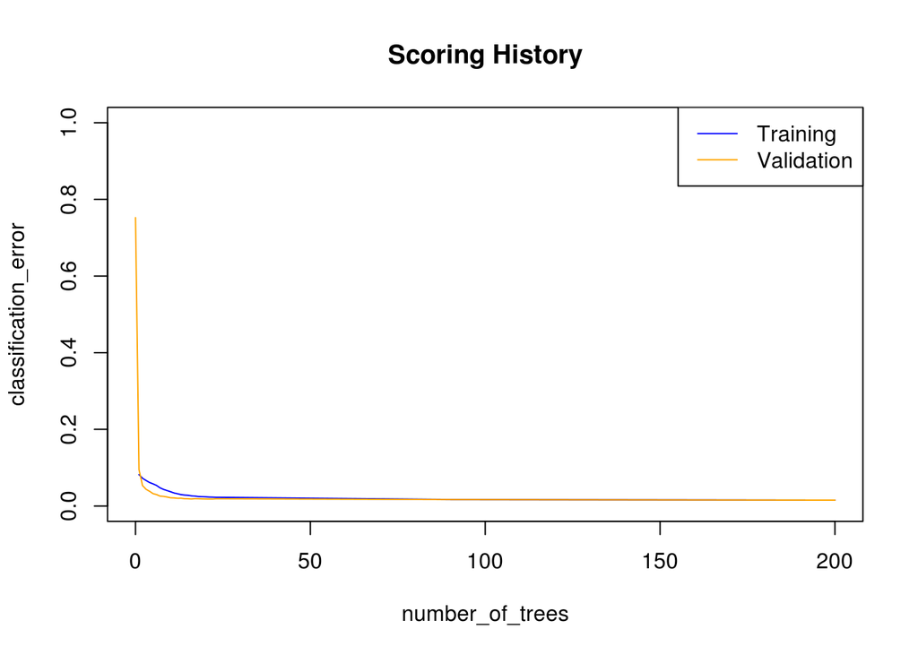

```r
plot(best)
```

#### Conclusion

Based on the scoring history and the summary table **tree number of 200** is used in the final model.

### Maximum tree depth

```r
drf_max_depth <- grid.search("drf", grid_id = "drf_max_depth", hyper_params = list(max_depth = c(10, 15, 20, 25, 30, 40, 50)))
```

```r
summarize.grid(drf_max_depth)
```

| max_depth | model_ids | logloss |
| --- | --- | --- |
| 50 | drf_max_depth_model_6 | 0.0956865175818738 |
| 40 | drf_max_depth_model_5 | 0.0956865175818738 |
| 30 | drf_max_depth_model_4 | 0.0956885076235373 |
| 25 | drf_max_depth_model_3 | 0.095853767429938 |
| 20 | drf_max_depth_model_2 | 0.0969942297454333 |
| 15 | drf_max_depth_model_1 | 0.106077729610593 |
| 10 | drf_max_depth_model_0 | 0.155012965666606 |

```r
best <- h2o.getModel(drf_max_depth@model_ids[[1]])
summarize.model(best)
```

| R Squared | Mean Squared Error |
| --- | --- |
| 0.9903056 | 0.0232187 |

|  | sitting | sittingdown | standing | standingup | walking | Error | Rate |
| --- | --- | --- | --- | --- | --- | --- | --- |
| sitting | 1516 | 0 | 0 | 1 | 0 | 0.0006592 | 1 / 1,517 |
| sittingdown | 7 | 358 | 3 | 4 | 5 | 0.0503979 | 19 / 377 |
| standing | 1 | 0 | 1407 | 2 | 5 | 0.0056537 | 8 / 1,415 |
| standingup | 5 | 16 | 11 | 359 | 8 | 0.1002506 | 40 / 399 |
| walking | 0 | 4 | 11 | 4 | 1273 | 0.0147059 | 19 / 1,292 |
| Totals | 1529 | 378 | 1432 | 370 | 1291 | 0.0174000 | 87 / 5,000 |

| variable | relative_importance | scaled_importance | percentage |
| --- | --- | --- | --- |
| y2 | 44495.121 | 1.0000000 | 0.1599565 |
| z1 | 42745.543 | 0.9606793 | 0.1536669 |
| z2 | 41354.031 | 0.9294060 | 0.1486645 |
| x3 | 26290.500 | 0.5908625 | 0.0945123 |
| y3 | 22483.738 | 0.5053079 | 0.0808273 |
| x4 | 19146.549 | 0.4303067 | 0.0688303 |
| x2 | 18680.207 | 0.4198260 | 0.0671539 |
| y1 | 17311.541 | 0.3890661 | 0.0622336 |
| z4 | 14470.301 | 0.3252110 | 0.0520196 |
| z3 | 12445.040 | 0.2796945 | 0.0447389 |
| y4 | 11027.787 | 0.2478426 | 0.0396440 |
| x1 | 7719.808 | 0.1734979 | 0.0277521 |

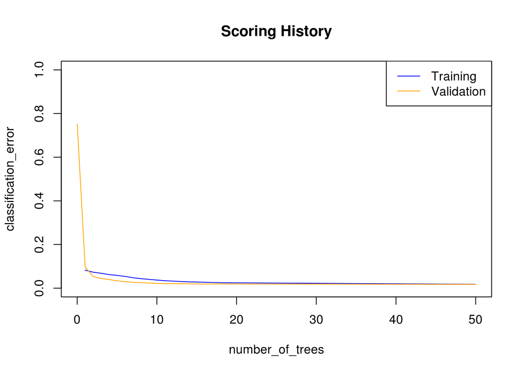

```r
plot(best)
```

#### Conclusion

Based on the scoring history and the summary table **maximum tree depth of 40** is used in the final model.

### Number of bins

```r
drf_nbins <- grid.search("drf", grid_id = "drf_nbins", hyper_params = list(nbins = c(10, 20, 30, 40, 50, 60, 70, 80, 90, 100, 200, 400)))
```

```r
summarize.grid(drf_nbins)
```

| nbins | model_ids | logloss |
| --- | --- | --- |
| 60 | drf_nbins_model_5 | 0.0938039830472743 |
| 50 | drf_nbins_model_4 | 0.094872784895523 |
| 90 | drf_nbins_model_8 | 0.0968248361751017 |
| 20 | drf_nbins_model_1 | 0.0969942297454333 |
| 30 | drf_nbins_model_2 | 0.0978355794273076 |
| 10 | drf_nbins_model_0 | 0.0981431851829374 |
| 40 | drf_nbins_model_3 | 0.0986377460537139 |
| 80 | drf_nbins_model_7 | 0.103794946543241 |
| 100 | drf_nbins_model_9 | 0.105410033134851 |
| 70 | drf_nbins_model_6 | 0.110149996066389 |
| 200 | drf_nbins_model_10 | 0.113473946593658 |
| 400 | drf_nbins_model_11 | 0.11891269763284 |

```r
best <- h2o.getModel(drf_nbins@model_ids[[1]])
summarize.model(best)
```

| R Squared | Mean Squared Error |
| --- | --- |
| 0.9898355 | 0.0243448 |

|  | sitting | sittingdown | standing | standingup | walking | Error | Rate |
| --- | --- | --- | --- | --- | --- | --- | --- |
| sitting | 1515 | 0 | 0 | 2 | 0 | 0.0013184 | 2 / 1,517 |
| sittingdown | 6 | 353 | 5 | 6 | 7 | 0.0636605 | 24 / 377 |
| standing | 0 | 1 | 1409 | 3 | 2 | 0.0042403 | 6 / 1,415 |
| standingup | 8 | 12 | 15 | 359 | 5 | 0.1002506 | 40 / 399 |
| walking | 1 | 2 | 12 | 4 | 1273 | 0.0147059 | 19 / 1,292 |
| Totals | 1530 | 368 | 1441 | 374 | 1287 | 0.0182000 | 91 / 5,000 |

| variable | relative_importance | scaled_importance | percentage |
| --- | --- | --- | --- |
| y2 | 44715.90 | 1.0000000 | 0.1611699 |
| z1 | 42551.39 | 0.9515941 | 0.1533683 |
| z2 | 40819.18 | 0.9128559 | 0.1471249 |
| x3 | 26381.97 | 0.5899907 | 0.0950887 |
| y3 | 22231.69 | 0.4971763 | 0.0801298 |
| x4 | 18818.47 | 0.4208452 | 0.0678276 |
| x2 | 18627.19 | 0.4165675 | 0.0671381 |
| y1 | 17621.59 | 0.3940787 | 0.0635136 |
| z4 | 14646.00 | 0.3275344 | 0.0527887 |
| z3 | 12653.65 | 0.2829787 | 0.0456076 |
| y4 | 10782.79 | 0.2411400 | 0.0388645 |
| x1 | 7596.01 | 0.1698727 | 0.0273784 |

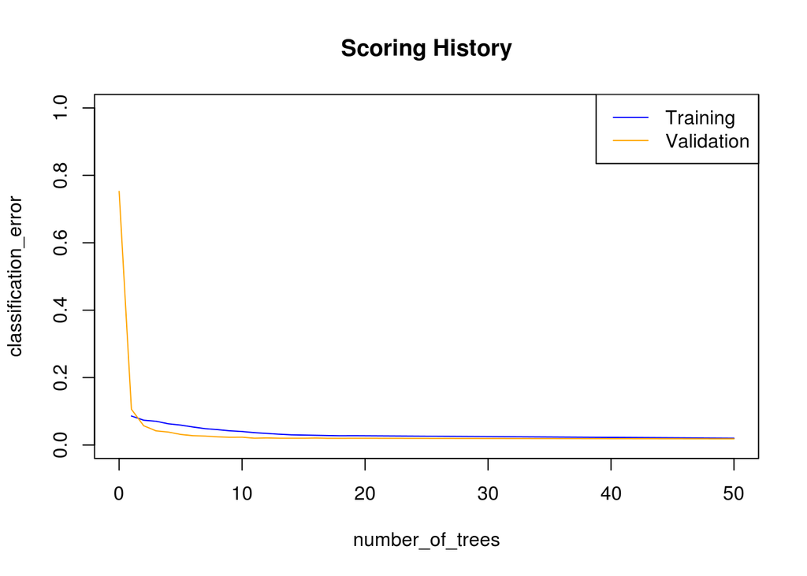

```r
plot(best)
```

#### Conclusion

Based on the scoring history and the summary table **number of bins of 60** is used in the final model.

### Best Model

```r
try(drf <- h2o.getModel("drf"), silent = TRUE)
if (!exists("drf")) {
  drf <- h2o.randomForest(model_id = "drf", x = d_x_idxs, y = d_y_idxs,
            training_frame = dx_train, validation_frame = dx_valid,
            mtries = -1, ntrees = 200, max_depth = 40, nbins = 60,
            stopping_rounds = 5, stopping_tolerance = 1e-3, seed = seed)
}
```

```r
summarize.model(drf)
```

| R Squared | Mean Squared Error |
| --- | --- |
| 0.9957604 | 0.010277 |

|  | sitting | sittingdown | standing | standingup | walking | Error | Rate |
| --- | --- | --- | --- | --- | --- | --- | --- |
| sitting | 12697 | 4 | 0 | 7 | 0 | 0.0008656 | 11 / 12,708 |
| sittingdown | 3 | 2751 | 17 | 35 | 22 | 0.0272277 | 77 / 2,828 |
| standing | 0 | 2 | 11779 | 8 | 39 | 0.0041427 | 49 / 11,828 |
| standingup | 6 | 62 | 27 | 2939 | 36 | 0.0426710 | 131 / 3,070 |
| walking | 1 | 14 | 27 | 7 | 10925 | 0.0044651 | 49 / 10,974 |
| Totals | 12707 | 2833 | 11850 | 2996 | 11022 | 0.0076555 | 317 / 41,408 |

| variable | relative_importance | scaled_importance | percentage |
| --- | --- | --- | --- |
| z1 | 1370242.1 | 1.0000000 | 0.1499150 |
| z2 | 1265951.2 | 0.9238887 | 0.1385048 |
| y2 | 1195087.0 | 0.8721721 | 0.1307517 |
| x3 | 831270.2 | 0.6066593 | 0.0909474 |
| y3 | 821099.3 | 0.5992367 | 0.0898346 |
| y1 | 724683.7 | 0.5288727 | 0.0792860 |
| x4 | 675938.8 | 0.4932988 | 0.0739529 |
| x2 | 638910.2 | 0.4662754 | 0.0699017 |
| z4 | 504290.2 | 0.3680300 | 0.0551732 |
| y4 | 438024.7 | 0.3196696 | 0.0479233 |
| z3 | 432789.4 | 0.3158489 | 0.0473505 |
| x1 | 241837.8 | 0.1764927 | 0.0264589 |

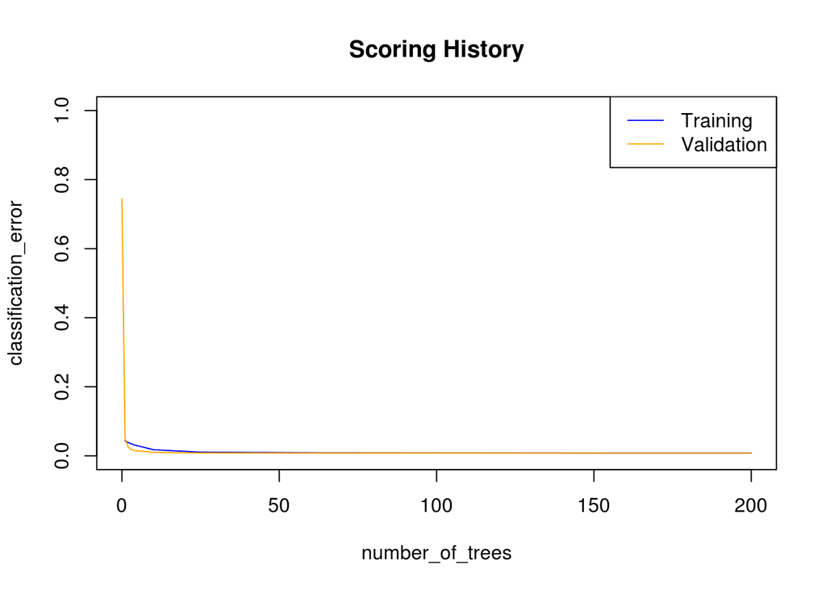

```r
plot(drf)
```

```r
summary(drf)
```

```
## Model Details:
## ==============
##
## H2OMultinomialModel: drf
## Model Key:  drf
## Model Summary:
##   number_of_trees model_size_in_bytes min_depth max_depth mean_depth
## 1            1000             9192408        14        40   28.14900
##   min_leaves max_leaves mean_leaves
## 1        153       1190   790.44500
##
## H2OMultinomialMetrics: drf
## ** Reported on training data. **
## Description: Metrics reported on Out-Of-Bag training samples
##
## Training Set Metrics:
## =====================
## Metrics reported on Out-Of-Bag training samples
##
## Extract training frame with `h2o.getFrame("train")`
## MSE: (Extract with `h2o.mse`) 0.01042277
## R^2: (Extract with `h2o.r2`) 0.9956619
## Logloss: (Extract with `h2o.logloss`) 0.04641963
## Confusion Matrix: Extract with `h2o.confusionMatrix(<model>,train = TRUE)`)
## =========================================================================
## Confusion Matrix: vertical: actual; across: predicted
##             sitting sittingdown standing standingup walking  Error
## sitting       25304           5        0         17       0 0.0009
## sittingdown       7        5856       33         56      46 0.0237
## standing          0           3    23601         15      86 0.0044
## standingup       10         120       67       6010      67 0.0421
## walking           0          20       83         26   21384 0.0060
## Totals        25321        6004    23784       6124   21583 0.0080
##                       Rate
## sitting     =  22 / 25,326
## sittingdown =  142 / 5,998
## standing    = 104 / 23,705
## standingup  =  264 / 6,274
## walking     = 129 / 21,513
## Totals      = 661 / 82,816
```

[output cut: 157 more lines]

```
##
## Variable Importances:
##    variable relative_importance scaled_importance percentage
## 1        z1      1370242.125000          1.000000   0.149915
## 2        z2      1265951.250000          0.923889   0.138505
## 3        y2      1195087.000000          0.872172   0.130752
## 4        x3       831270.187500          0.606659   0.090947
## 5        y3       821099.312500          0.599237   0.089835
## 6        y1       724683.687500          0.528873   0.079286
## 7        x4       675938.812500          0.493299   0.073953
## 8        x2       638910.250000          0.466275   0.069902
## 9        z4       504290.187500          0.368030   0.055173
## 10       y4       438024.687500          0.319670   0.047923
## 11       z3       432789.437500          0.315849   0.047350
## 12       x1       241837.781250          0.176493   0.026459
```

## Gradient Boosting Method (Grid Search)

- Number of trees (ntrees): 50
- Maximum tree depth (max_depth): 5
- For numerical columns - real/int -, build a histogram of - at least - this many bins, then split at the best point (nbins): 20
- Learning rate (learn_rate): 0.1

Grid search is used to find the best parameter in order to find the best parameter.

### Number of trees

```r
gbm_ntrees <- grid.search("gbm", grid_id = "gbm_ntrees", hyper_params = list(ntrees = c(25, 50, 100, 200, 300, 400, 500)))
```

```r
summarize.grid(gbm_ntrees)
```

| ntrees | model_ids | logloss |
| --- | --- | --- |
| 300 | gbm_ntrees_model_4 | 0.0448762755118737 |
| 400 | gbm_ntrees_model_5 | 0.0469103501624362 |
| 200 | gbm_ntrees_model_3 | 0.047184279215981 |
| 500 | gbm_ntrees_model_6 | 0.0482797057038402 |
| 100 | gbm_ntrees_model_2 | 0.0630101921488298 |
| 50 | gbm_ntrees_model_1 | 0.0955158652495429 |
| 25 | gbm_ntrees_model_0 | 0.18063656206619 |

```r
best <- h2o.getModel(gbm_ntrees@model_ids[[1]])
summarize.model(best)
```

| R Squared | Mean Squared Error |
| --- | --- |
| 0.9953262 | 0.0111941 |

|  | sitting | sittingdown | standing | standingup | walking | Error | Rate |
| --- | --- | --- | --- | --- | --- | --- | --- |
| sitting | 1514 | 0 | 0 | 3 | 0 | 0.0019776 | 3 / 1,517 |
| sittingdown | 2 | 357 | 3 | 7 | 8 | 0.0530504 | 20 / 377 |
| standing | 0 | 0 | 1408 | 4 | 3 | 0.0049470 | 7 / 1,415 |
| standingup | 2 | 12 | 8 | 374 | 3 | 0.0626566 | 25 / 399 |
| walking | 0 | 1 | 9 | 5 | 1277 | 0.0116099 | 15 / 1,292 |
| Totals | 1518 | 370 | 1428 | 393 | 1291 | 0.0140000 | 70 / 5,000 |

| variable | relative_importance | scaled_importance | percentage |
| --- | --- | --- | --- |
| z1 | 8610.1807 | 1.0000000 | 0.2830338 |
| y2 | 5479.3486 | 0.6363802 | 0.1801171 |
| x3 | 4800.5610 | 0.5575448 | 0.1578040 |
| z2 | 2186.0842 | 0.2538953 | 0.0718609 |
| x4 | 2081.9392 | 0.2417997 | 0.0684375 |
| z3 | 1995.1437 | 0.2317191 | 0.0655843 |
| y3 | 1357.4736 | 0.1576591 | 0.0446229 |
| z4 | 1227.0133 | 0.1425073 | 0.0403344 |
| y1 | 1037.5422 | 0.1205018 | 0.0341061 |
| x2 | 726.8911 | 0.0844223 | 0.0238944 |
| x1 | 581.1485 | 0.0674955 | 0.0191035 |
| y4 | 337.7117 | 0.0392224 | 0.0111013 |

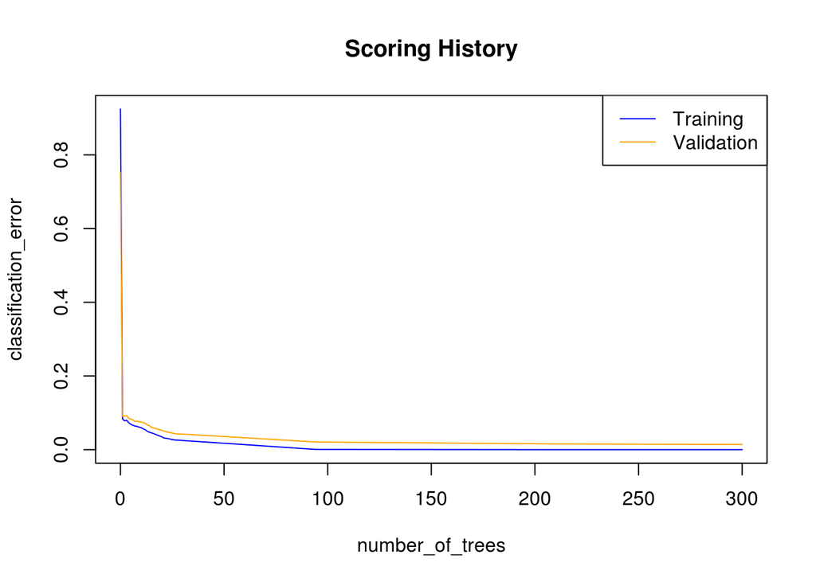

```r
plot(best)
```

#### Conclusion

Based on the scoring history and the summary table **tree number of 300** is used in the final model.

### Maximum tree depth

```r
gbm_max_depth <- grid.search("gbm", grid_id = "gbm_max_depth", hyper_params = list(max_depth = c(10, 20, 30, 40, 50, 60, 70, 80, 90, 100, 110, 120, 130, 140, 150)))
```

```r
summarize.grid(gbm_max_depth)
```

| max_depth | model_ids | logloss |
| --- | --- | --- |
| 110 | gbm_max_depth_model_22 | 0.0442365351907187 |
| 120 | gbm_max_depth_model_23 | 0.0442365460905547 |
| 100 | gbm_max_depth_model_20 | 0.0443688690253198 |
| 80 | gbm_max_depth_model_16 | 0.0445903584633339 |
| 90 | gbm_max_depth_model_17 | 0.0448180131820391 |
| 150 | gbm_max_depth_model_26 | 0.0448206862985048 |
| 60 | gbm_max_depth_model_14 | 0.0452961251075925 |
| 140 | gbm_max_depth_model_25 | 0.0454461574118431 |
| 70 | gbm_max_depth_model_15 | 0.0456685382586156 |
| 50 | gbm_max_depth_model_6 | 0.0458133875067019 |
| 40 | gbm_max_depth_model_5 | 0.0461365964995269 |
| 25 | gbm_max_depth_model_3 | 0.0466608722114162 |
| 30 | gbm_max_depth_model_4 | 0.047065437337434 |
| 130 | gbm_max_depth_model_24 | 0.047343077638955 |
| 20 | gbm_max_depth_model_2 | 0.0474906342543335 |
| 15 | gbm_max_depth_model_1 | 0.0484637318146791 |
| 10 | gbm_max_depth_model_0 | 0.0520902290914669 |

```r
best <- h2o.getModel(gbm_max_depth@model_ids[[1]])
summarize.model(best)
```

| R Squared | Mean Squared Error |
| --- | --- |
| 0.9950026 | 0.0119693 |

|  | sitting | sittingdown | standing | standingup | walking | Error | Rate |
| --- | --- | --- | --- | --- | --- | --- | --- |
| sitting | 1516 | 0 | 0 | 1 | 0 | 0.0006592 | 1 / 1,517 |
| sittingdown | 3 | 359 | 0 | 10 | 5 | 0.0477454 | 18 / 377 |
| standing | 0 | 0 | 1408 | 4 | 3 | 0.0049470 | 7 / 1,415 |
| standingup | 3 | 12 | 10 | 371 | 3 | 0.0701754 | 28 / 399 |
| walking | 0 | 4 | 9 | 5 | 1274 | 0.0139319 | 18 / 1,292 |
| Totals | 1522 | 375 | 1427 | 391 | 1285 | 0.0144000 | 72 / 5,000 |

| variable | relative_importance | scaled_importance | percentage |
| --- | --- | --- | --- |
| z1 | 8145.8145 | 1.0000000 | 0.2561847 |
| y2 | 5547.2227 | 0.6809905 | 0.1744594 |
| x3 | 5381.5537 | 0.6606526 | 0.1692491 |
| z2 | 2363.7212 | 0.2901762 | 0.0743387 |
| z3 | 2210.2744 | 0.2713387 | 0.0695128 |
| x4 | 1980.7172 | 0.2431577 | 0.0622933 |
| z4 | 1684.2338 | 0.2067606 | 0.0529689 |
| y3 | 1389.0414 | 0.1705221 | 0.0436852 |
| y1 | 1069.6846 | 0.1313171 | 0.0336414 |
| x2 | 855.8902 | 0.1050712 | 0.0269176 |
| x1 | 606.1558 | 0.0744132 | 0.0190635 |
| y4 | 562.3391 | 0.0690341 | 0.0176855 |

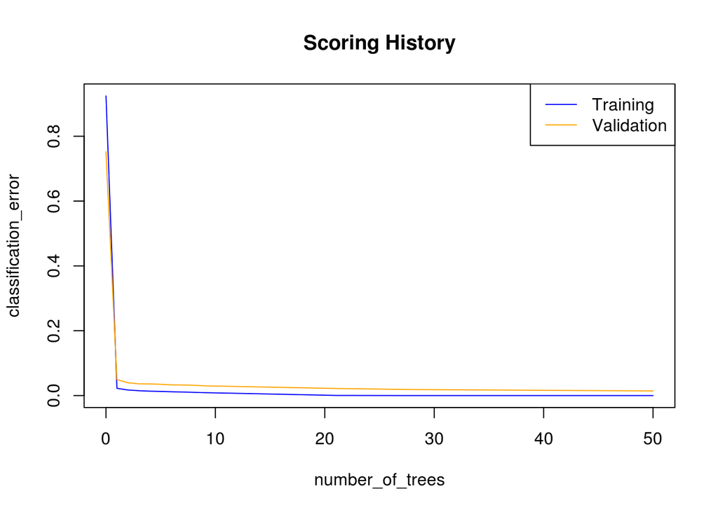

```r
plot(best)
```

#### Conclusion

Based on the scoring history and the summary table **maximum tree depth of 110** is used in the final model.

### Number of bins

```r
gbm_nbins <- grid.search("gbm", grid_id = "gbm_nbins", hyper_params = list(nbins = c(10, 20, 30, 40, 50, 60, 70, 80, 90, 100, 200, 400)))
```

```r
summarize.grid(gbm_nbins)
```

| nbins | model_ids | logloss |
| --- | --- | --- |
| 60 | gbm_nbins_model_5 | 0.0938380724324759 |
| 50 | gbm_nbins_model_4 | 0.0941400260963724 |
| 90 | gbm_nbins_model_8 | 0.0942678275111212 |
| 30 | gbm_nbins_model_2 | 0.0945241582683291 |
| 70 | gbm_nbins_model_6 | 0.0954178890330435 |
| 20 | gbm_nbins_model_1 | 0.095513661609563 |
| 10 | gbm_nbins_model_0 | 0.0960069520059258 |
| 40 | gbm_nbins_model_3 | 0.0961830132047229 |
| 100 | gbm_nbins_model_9 | 0.0966279547374323 |
| 400 | gbm_nbins_model_11 | 0.0972695145169758 |
| 200 | gbm_nbins_model_10 | 0.0976499131694835 |
| 80 | gbm_nbins_model_7 | 0.097805583004053 |

```r
best <- h2o.getModel(gbm_nbins@model_ids[[1]])
summarize.model(best)
```

| R Squared | Mean Squared Error |
| --- | --- |
| 0.9891912 | 0.025888 |

|  | sitting | sittingdown | standing | standingup | walking | Error | Rate |
| --- | --- | --- | --- | --- | --- | --- | --- |
| sitting | 1515 | 0 | 0 | 2 | 0 | 0.0013184 | 2 / 1,517 |
| sittingdown | 7 | 337 | 5 | 15 | 13 | 0.1061008 | 40 / 377 |
| standing | 0 | 0 | 1401 | 5 | 9 | 0.0098940 | 14 / 1,415 |
| standingup | 6 | 26 | 16 | 343 | 8 | 0.1403509 | 56 / 399 |
| walking | 0 | 5 | 14 | 5 | 1268 | 0.0185759 | 24 / 1,292 |
| Totals | 1528 | 368 | 1436 | 370 | 1298 | 0.0272000 | 136 / 5,000 |

| variable | relative_importance | scaled_importance | percentage |
| --- | --- | --- | --- |
| z1 | 8539.3350 | 1.0000000 | 0.2814304 |
| y2 | 5398.8950 | 0.6322383 | 0.1779311 |
| x3 | 4675.8433 | 0.5475653 | 0.1541015 |
| z2 | 2281.9878 | 0.2672325 | 0.0752073 |
| x4 | 2120.4263 | 0.2483128 | 0.0698828 |
| z3 | 1949.5345 | 0.2283005 | 0.0642507 |
| y3 | 1365.9108 | 0.1599552 | 0.0450162 |
| z4 | 1262.1918 | 0.1478091 | 0.0415980 |
| y1 | 1048.9745 | 0.1228403 | 0.0345710 |
| x2 | 689.8426 | 0.0807841 | 0.0227351 |
| x1 | 635.4268 | 0.0744117 | 0.0209417 |
| y4 | 374.2506 | 0.0438267 | 0.0123342 |

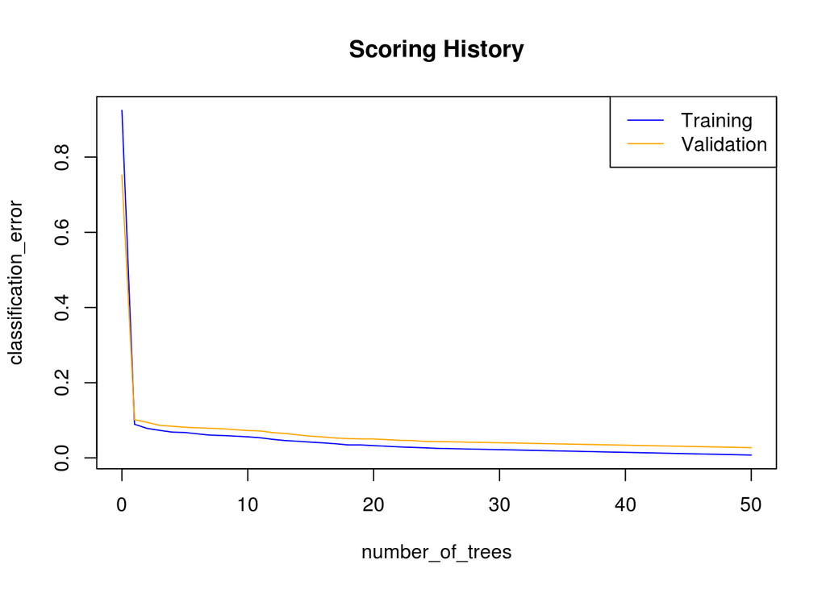

```r
plot(best)
```

#### Conclusion

Based on the scoring history and the summary table **number of bins of 60** is used in the final model.

### Learning rate

```r
gbm_rate <- grid.search("gbm", grid_id = "gbm_rate", hyper_params = list(learn_rate = c(0.01, 0.05, 0.1, 0.2, 0.3, 0.4, 0.5, 0.6, 0.7, 0.8)))
```

```r
summarize.grid(gbm_rate)
```

| learn_rate | model_ids | logloss |
| --- | --- | --- |
| 0.5 | gbm_rate_model_6 | 0.0507369799607001 |
| 0.7 | gbm_rate_model_15 | 0.0515207870999115 |
| 0.6 | gbm_rate_model_14 | 0.0518336785532922 |
| 0.4 | gbm_rate_model_5 | 0.0524587242882682 |
| 0.3 | gbm_rate_model_4 | 0.0528015350991478 |
| 0.2 | gbm_rate_model_3 | 0.0625499711104597 |
| 0.8 | gbm_rate_model_16 | 0.0928042547092146 |
| 0.1 | gbm_rate_model_2 | 0.095513661609563 |
| 0.05 | gbm_rate_model_1 | 0.180453774584555 |
| 0.01 | gbm_rate_model_0 | 0.780442033737077 |

```r
best <- h2o.getModel(gbm_rate@model_ids[[1]])
summarize.model(best)
```

| R Squared | Mean Squared Error |
| --- | --- |
| 0.9946037 | 0.0129245 |

|  | sitting | sittingdown | standing | standingup | walking | Error | Rate |
| --- | --- | --- | --- | --- | --- | --- | --- |
| sitting | 1514 | 1 | 0 | 2 | 0 | 0.0019776 | 3 / 1,517 |
| sittingdown | 4 | 352 | 0 | 13 | 8 | 0.0663130 | 25 / 377 |
| standing | 0 | 0 | 1406 | 3 | 6 | 0.0063604 | 9 / 1,415 |
| standingup | 2 | 14 | 8 | 370 | 5 | 0.0726817 | 29 / 399 |
| walking | 0 | 2 | 8 | 6 | 1276 | 0.0123839 | 16 / 1,292 |
| Totals | 1520 | 369 | 1422 | 394 | 1295 | 0.0164000 | 82 / 5,000 |

| variable | relative_importance | scaled_importance | percentage |
| --- | --- | --- | --- |
| z1 | 2064.73486 | 1.0000000 | 0.2734118 |
| y2 | 1529.77686 | 0.7409072 | 0.2025728 |
| y3 | 1237.53271 | 0.5993664 | 0.1638738 |
| x4 | 542.79370 | 0.2628878 | 0.0718766 |
| z3 | 486.61157 | 0.2356775 | 0.0644370 |
| z2 | 421.05658 | 0.2039277 | 0.0557562 |
| x3 | 370.38709 | 0.1793872 | 0.0490466 |
| z4 | 312.15829 | 0.1511857 | 0.0413359 |
| y1 | 271.68750 | 0.1315847 | 0.0359768 |
| x2 | 144.19551 | 0.0698373 | 0.0190943 |
| y4 | 87.66422 | 0.0424579 | 0.0116085 |
| x1 | 83.14150 | 0.0402674 | 0.0110096 |

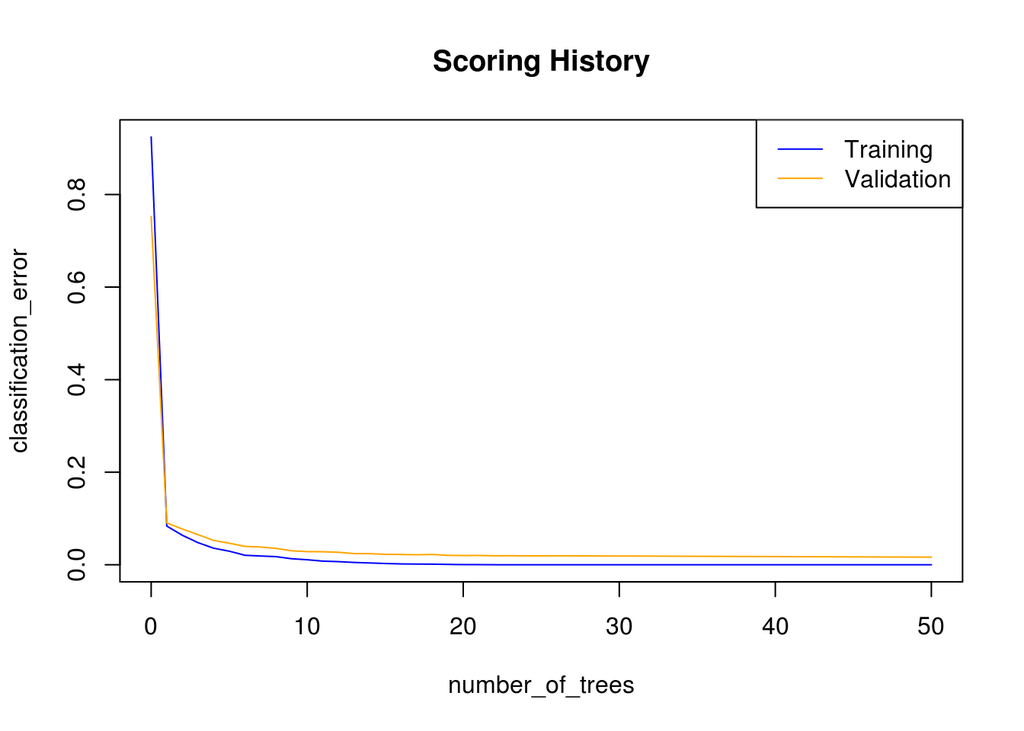

```r
plot(best)
```

#### Conclusion

Based on the scoring history and the summary table **learning rate of 0.5** is used in the final model.

### Best Model

```r
try(gbm <- h2o.getModel("gbm"), silent = TRUE)
if (!exists("gbm")) {
  gbm <- h2o.gbm(model_id = "gbm", x = d_x_idxs, y = d_y_idxs,
            training_frame = dx_train, validation_frame = dx_valid,
            ntrees = 300, max_depth = 110, nbins = 60, learn_rate = 0.5,
            stopping_rounds = 5, stopping_tolerance = 1e-3, seed = seed)
}
```

```r
summarize.model(drf)
```

[output not shown]

|  | sitting | sittingdown | standing | standingup | walking | Error | Rate |
| --- | --- | --- | --- | --- | --- | --- | --- |
| sitting | 12697 | 4 | 0 | 7 | 0 | 0.0008656 | 11 / 12,708 |
| sittingdown | 3 | 2751 | 17 | 35 | 22 | 0.0272277 | 77 / 2,828 |
| standing | 0 | 2 | 11779 | 8 | 39 | 0.0041427 | 49 / 11,828 |
| standingup | 6 | 62 | 27 | 2939 | 36 | 0.0426710 | 131 / 3,070 |
| walking | 1 | 14 | 27 | 7 | 10925 | 0.0044651 | 49 / 10,974 |
| Totals | 12707 | 2833 | 11850 | 2996 | 11022 | 0.0076555 | 317 / 41,408 |

| variable | relative_importance | scaled_importance | percentage |
| --- | --- | --- | --- |
| z1 | 1370242.1 | 1.0000000 | 0.1499150 |
| z2 | 1265951.2 | 0.9238887 | 0.1385048 |
| y2 | 1195087.0 | 0.8721721 | 0.1307517 |
| x3 | 831270.2 | 0.6066593 | 0.0909474 |
| y3 | 821099.3 | 0.5992367 | 0.0898346 |
| y1 | 724683.7 | 0.5288727 | 0.0792860 |
| x4 | 675938.8 | 0.4932988 | 0.0739529 |
| x2 | 638910.2 | 0.4662754 | 0.0699017 |
| z4 | 504290.2 | 0.3680300 | 0.0551732 |
| y4 | 438024.7 | 0.3196696 | 0.0479233 |
| z3 | 432789.4 | 0.3158489 | 0.0473505 |
| x1 | 241837.8 | 0.1764927 | 0.0264589 |

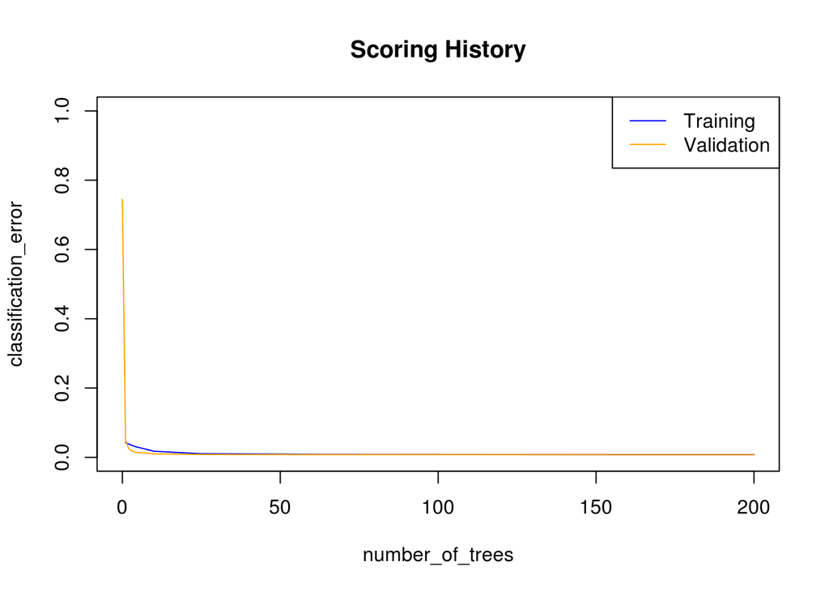

```r
plot(drf)
```

```r
summary(drf)
```

```
## Model Details:
## ==============
##
## H2OMultinomialModel: drf
## Model Key:  drf
## Model Summary:
##   number_of_trees model_size_in_bytes min_depth max_depth mean_depth
## 1            1000             9192408        14        40   28.14900
##   min_leaves max_leaves mean_leaves
## 1        153       1190   790.44500
##
## H2OMultinomialMetrics: drf
## ** Reported on training data. **
## Description: Metrics reported on Out-Of-Bag training samples
##
## Training Set Metrics:
## =====================
## Metrics reported on Out-Of-Bag training samples
##
## Extract training frame with `h2o.getFrame("train")`
## MSE: (Extract with `h2o.mse`) 0.01042277
## R^2: (Extract with `h2o.r2`) 0.9956619
## Logloss: (Extract with `h2o.logloss`) 0.04641963
## Confusion Matrix: Extract with `h2o.confusionMatrix(<model>,train = TRUE)`)
## =========================================================================
## Confusion Matrix: vertical: actual; across: predicted
##             sitting sittingdown standing standingup walking  Error
## sitting       25304           5        0         17       0 0.0009
## sittingdown       7        5856       33         56      46 0.0237
## standing          0           3    23601         15      86 0.0044
## standingup       10         120       67       6010      67 0.0421
## walking           0          20       83         26   21384 0.0060
## Totals        25321        6004    23784       6124   21583 0.0080
##                       Rate
## sitting     =  22 / 25,326
## sittingdown =  142 / 5,998
## standing    = 104 / 23,705
## standingup  =  264 / 6,274
## walking     = 129 / 21,513
## Totals      = 661 / 82,816
```

[output cut: 157 more lines]

```
##
## Variable Importances:
##    variable relative_importance scaled_importance percentage
## 1        z1      1370242.125000          1.000000   0.149915
## 2        z2      1265951.250000          0.923889   0.138505
## 3        y2      1195087.000000          0.872172   0.130752
## 4        x3       831270.187500          0.606659   0.090947
## 5        y3       821099.312500          0.599237   0.089835
## 6        y1       724683.687500          0.528873   0.079286
## 7        x4       675938.812500          0.493299   0.073953
## 8        x2       638910.250000          0.466275   0.069902
## 9        z4       504290.187500          0.368030   0.055173
## 10       y4       438024.687500          0.319670   0.047923
## 11       z3       432789.437500          0.315849   0.047350
## 12       x1       241837.781250          0.176493   0.026459
```

## Deep Learning (Grid Search)

- Activation function (activation): Rectifier
- Hidden layer sizes (hidden): 200, 200
- How many times the dataset should be iterated (epochs): 10

Grid search is used to find the best parameter in order to find the best parameter.

### Activation function

```r
deeplearning_activation <- grid.search("deeplearning", grid_id = "deeplearning_activation", hyper_params = list(activation = c("Tanh", "TanhWithDropout", "Maxout", "MaxoutWithDropout", "Rectifier", "RectifierWithDropout")))
```

```r
summarize.grid(deeplearning_activation)
```

| activation | model_ids | logloss |
| --- | --- | --- |
| Tanh | deeplearning_activation_model_0 | 0.0990491806870204 |
| Rectifier | deeplearning_activation_model_4 | 0.119872807494685 |
| Maxout | deeplearning_activation_model_2 | 0.160579673102152 |
| RectifierWithDropout | deeplearning_activation_model_5 | 0.20826789730357 |
| MaxoutWithDropout | deeplearning_activation_model_3 | 0.228974026753746 |
| TanhWithDropout | deeplearning_activation_model_1 | 0.271704796079718 |

```r
best <- h2o.getModel(deeplearning_activation@model_ids[[1]])
summarize.model(best)
```

| R Squared | Mean Squared Error |
| --- | --- |
| 0.9895252 | 0.025088 |

|  | sitting | sittingdown | standing | standingup | walking | Error | Rate |
| --- | --- | --- | --- | --- | --- | --- | --- |
| sitting | 1509 | 1 | 0 | 7 | 0 | 0.0052736 | 8 / 1,517 |
| sittingdown | 8 | 346 | 6 | 8 | 9 | 0.0822281 | 31 / 377 |
| standing | 0 | 3 | 1386 | 13 | 13 | 0.0204947 | 29 / 1,415 |
| standingup | 3 | 17 | 13 | 355 | 11 | 0.1102757 | 44 / 399 |
| walking | 0 | 6 | 25 | 8 | 1253 | 0.0301858 | 39 / 1,292 |
| Totals | 1520 | 373 | 1430 | 391 | 1286 | 0.0302000 | 151 / 5,000 |

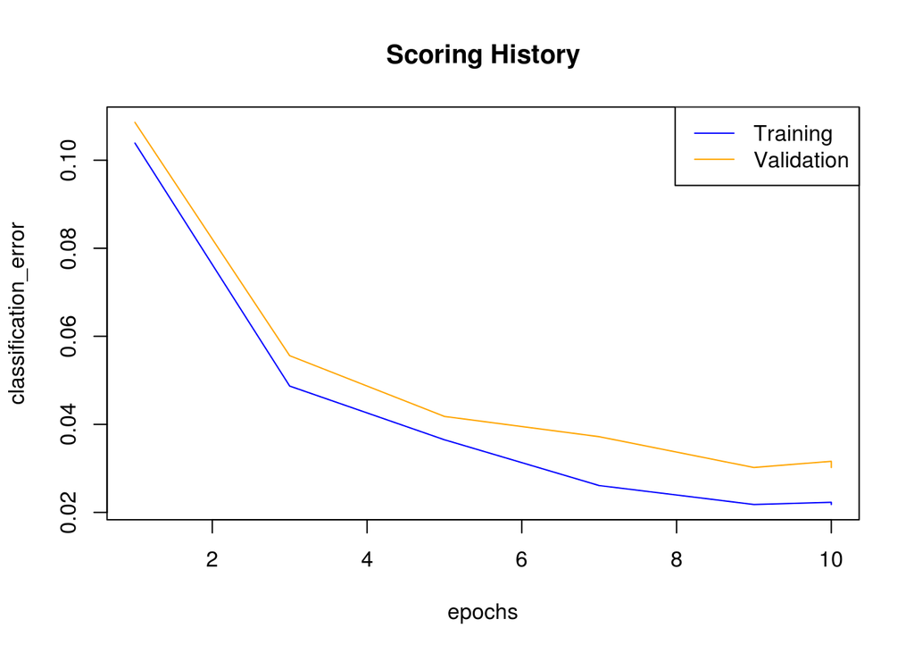

```r
plot(best)
```

#### Conclusion

Based on the scoring history and the summary table **activation of Tanh** is used in the final model.

### Hidden layer size

```r
deeplearning_hidden <- grid.search("deeplearning", grid_id = "deeplearning_hidden", hyper_params = list(hidden = c(c(100, 100), c(200, 200), c(300, 300), c(400, 400))))
```

```r
summarize.grid(deeplearning_hidden)
```

| hidden | model_ids | logloss |
| --- | --- | --- |
| 200 | deeplearning_hidden_model_9 | 0.193677905261464 |
| 300 | deeplearning_hidden_model_6 | 0.197121731332955 |
| 400 | deeplearning_hidden_model_8 | 0.197948531697683 |
| 100 | deeplearning_hidden_model_0 | 0.209205296088972 |

```r
best <- h2o.getModel(deeplearning_hidden@model_ids[[1]])
summarize.model(best)
```

| R Squared | Mean Squared Error |
| --- | --- |
| 0.9807366 | 0.0461373 |

|  | sitting | sittingdown | standing | standingup | walking | Error | Rate |
| --- | --- | --- | --- | --- | --- | --- | --- |
| sitting | 1512 | 3 | 0 | 2 | 0 | 0.0032960 | 5 / 1,517 |
| sittingdown | 16 | 314 | 19 | 12 | 16 | 0.1671088 | 63 / 377 |
| standing | 0 | 6 | 1377 | 7 | 25 | 0.0268551 | 38 / 1,415 |
| standingup | 5 | 40 | 28 | 313 | 13 | 0.2155388 | 86 / 399 |
| walking | 0 | 16 | 35 | 4 | 1237 | 0.0425697 | 55 / 1,292 |
| Totals | 1533 | 379 | 1459 | 338 | 1291 | 0.0494000 | 247 / 5,000 |

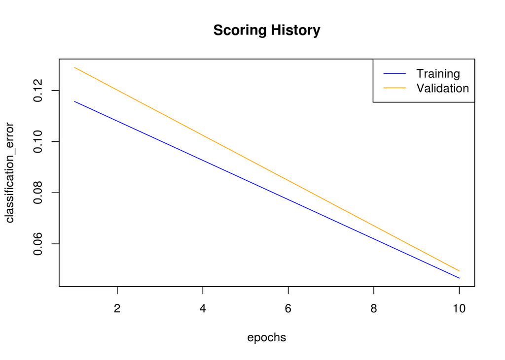

```r
plot(best)
```

#### Conclusion

Based on the scoring history and the summary table **hidden layer size of 200** is used in the final model.

### Epoch

```r
deeplearning_epoch <- grid.search("deeplearning", grid_id = "deeplearning_epoch", hyper_params = list(epochs = c(10, 20, 30, 40, 50, 60, 70, 80, 90, 100)))
```

```r
summarize.grid(deeplearning_epoch)
```

| epochs | model_ids | logloss |
| --- | --- | --- |
| 30 | deeplearning_epoch_model_7 | 0.0800698879357943 |
| 50 | deeplearning_epoch_model_1 | 0.0802804809074621 |
| 80 | deeplearning_epoch_model_12 | 0.0806864055221505 |
| 400 | deeplearning_epoch_model_4 | 0.0848429630216234 |
| 40 | deeplearning_epoch_model_8 | 0.0854955234766507 |
| 70 | deeplearning_epoch_model_11 | 0.0875845719483958 |
| 200 | deeplearning_epoch_model_3 | 0.0882172773348608 |
| 90 | deeplearning_epoch_model_13 | 0.0887746188921315 |
| 60 | deeplearning_epoch_model_10 | 0.0902103780570339 |
| 100 | deeplearning_epoch_model_2 | 0.0916135265377125 |
| 20 | deeplearning_epoch_model_6 | 0.0937389435813184 |
| 10 | deeplearning_activation_model_4 | 0.119872807494685 |

```r
best <- h2o.getModel(deeplearning_epoch@model_ids[[1]])
summarize.model(best)
```

| R Squared | Mean Squared Error |
| --- | --- |
| 0.992155 | 0.0187894 |

|  | sitting | sittingdown | standing | standingup | walking | Error | Rate |
| --- | --- | --- | --- | --- | --- | --- | --- |
| sitting | 1515 | 0 | 0 | 2 | 0 | 0.0013184 | 2 / 1,517 |
| sittingdown | 4 | 359 | 2 | 4 | 8 | 0.0477454 | 18 / 377 |
| standing | 0 | 3 | 1390 | 8 | 14 | 0.0176678 | 25 / 1,415 |
| standingup | 2 | 26 | 9 | 356 | 6 | 0.1077694 | 43 / 399 |
| walking | 0 | 4 | 16 | 7 | 1265 | 0.0208978 | 27 / 1,292 |
| Totals | 1521 | 392 | 1417 | 377 | 1293 | 0.0230000 | 115 / 5,000 |

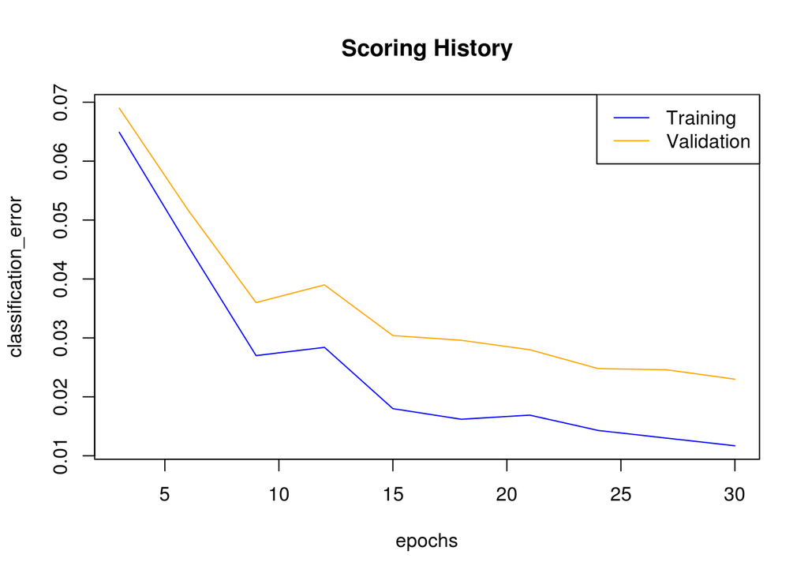

```r
plot(best)
```

#### Conclusion

Based on the scoring history and the summary table **epoch of 30** is used in the final model.

### Best Model

```r
try(deeplearning <- h2o.getModel("deeplearning"), silent = TRUE)
if (!exists("deeplearning")) {
  deeplearning <- h2o.deeplearning(model_id = "deeplearning", x = d_x_idxs, y = d_y_idxs,
            training_frame = dx_train, validation_frame = dx_valid,
            activation = "Tanh", hidden = c(200,200), epochs = 30,
            stopping_rounds = 5, stopping_tolerance = 1e-3, seed = seed)
}
```

```r
summarize.model(deeplearning)
```

| R Squared | Mean Squared Error |
| --- | --- |
| 0.9962416 | 0.0091104 |

|  | sitting | sittingdown | standing | standingup | walking | Error | Rate |
| --- | --- | --- | --- | --- | --- | --- | --- |
| sitting | 12686 | 8 | 0 | 14 | 0 | 0.0017312 | 22 / 12,708 |
| sittingdown | 5 | 2747 | 17 | 49 | 10 | 0.0286421 | 81 / 2,828 |
| standing | 0 | 16 | 11753 | 27 | 32 | 0.0063409 | 75 / 11,828 |
| standingup | 11 | 76 | 32 | 2928 | 23 | 0.0462541 | 142 / 3,070 |
| walking | 1 | 36 | 76 | 20 | 10841 | 0.0121196 | 133 / 10,974 |
| Totals | 12703 | 2883 | 11878 | 3038 | 10906 | 0.0109399 | 453 / 41,408 |

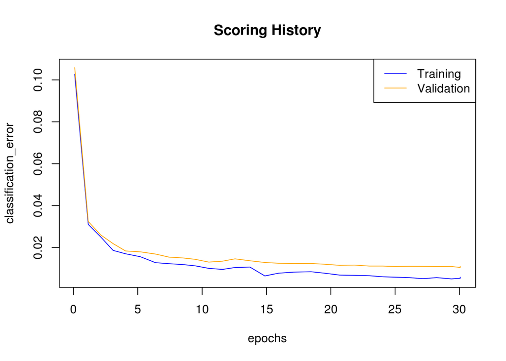

```r
plot(deeplearning)
```

```r
summary(deeplearning)
```

```
## Model Details:
## ==============
##
## H2OMultinomialModel: deeplearning
## Model Key:  deeplearning
## Status of Neuron Layers: predicting class, 5-class classification, multinomial distribution, CrossEntropy loss, 43,805 weights/biases, 522.7 KB, 2,489,449 training samples, mini-batch size 1
##   layer units    type dropout       l1       l2 mean_rate rate_RMS
## 1     1    12   Input  0.00 %
## 2     2   200    Tanh  0.00 % 0.000000 0.000000  0.008093 0.008362
## 3     3   200    Tanh  0.00 % 0.000000 0.000000  0.066477 0.089501
## 4     4     5 Softmax         0.000000 0.000000  0.004763 0.004666
##   momentum mean_weight weight_RMS mean_bias bias_RMS
## 1
## 2 0.000000   -0.002624   0.342052  0.030387 0.205100
## 3 0.000000   -0.000306   0.229109  0.140714 0.835524
## 4 0.000000   -0.036024   0.635307 -0.637206 0.530427
##
## H2OMultinomialMetrics: deeplearning
## ** Reported on training data. **
## Description: Metrics reported on temporary training frame with 9926 samples
##
## Training Set Metrics:
## =====================
## Metrics reported on temporary training frame with 9926 samples
##
## MSE: (Extract with `h2o.mse`) 0.004759427
## R^2: (Extract with `h2o.r2`) 0.9980334
## Logloss: (Extract with `h2o.logloss`) 0.01830266
## Confusion Matrix: Extract with `h2o.confusionMatrix(<model>,train = TRUE)`)
## =========================================================================
## Confusion Matrix: vertical: actual; across: predicted
##             sitting sittingdown standing standingup walking  Error
## sitting        3059           0        0          0       0 0.0000
## sittingdown       0         743        5          3       1 0.0120
## standing          0           0     2751          3       7 0.0036
## standingup        3           8        7        745       2 0.0261
## walking           0           3       13          3    2570 0.0073
## Totals         3062         754     2776        754    2580 0.0058
##                     Rate
## sitting     =  0 / 3,059
```

[output cut: 133 more lines]

```
## 31        311 2489449.000000      0.00476     0.99803          0.01830
##    training_classification_error validation_MSE validation_r2
## 26                       0.00564        0.00936       0.99614
## 27                       0.00514        0.00922       0.99620
## 28                       0.00564        0.00930       0.99616
## 29                       0.00504        0.00920       0.99621
## 30                       0.00534        0.00898       0.99630
## 31                       0.00584        0.00911       0.99624
##    validation_logloss validation_classification_error
## 26            0.04531                         0.01106
## 27            0.04483                         0.01101
## 28            0.04653                         0.01092
## 29            0.04499                         0.01096
## 30            0.04460                         0.01051
## 31            0.04321                         0.01094
```

# Comparsion

```r
models <- data.frame(get.metrics("Distributed Random Forest", drf))
models <- rbind(models, data.frame(get.metrics("Gradient Boosting Method", gbm)))
models <- rbind(models, data.frame(get.metrics("Deep Learning", deeplearning)))
kable(models)
```

| name | r2 | mse | logloss |
| --- | --- | --- | --- |
| Distributed Random Forest | 0.9957604 | 0.0102770 | 0.0462916 |
| Gradient Boosting Method | 0.9974315 | 0.0062261 | 0.0266412 |
| Deep Learning | 0.9962416 | 0.0091104 | 0.0432102 |

## Gradient Boosting Method

The **Gradient Boosting Method** performs the best out of the three model. It has the accuracy of 99.29% which is close to the accuracy of the original research (99.4%).

```r
performance <- h2o.performance(gbm, newdata = dx_test)
kable(data.frame(get.metrics("Performance", performance)))
```

| name | r2 | mse | logloss |
| --- | --- | --- | --- |
| Performance | 0.9975843 | 0.0058225 | 0.0251063 |

```r
print(kable(h2o.confusionMatrix(performance)))
```

```
##
##
##                sitting   sittingdown   standing   standingup   walking       Error  Rate
## ------------  --------  ------------  ---------  -----------  --------  ----------  -------------
## sitting          12585             1          0           10         1   0.0009526  12 / 12,597
## sittingdown          3          2930         14           35        19   0.0236588  71 / 3,001
## standing             0             0      11792            5        40   0.0038016  45 / 11,837
## standingup           8            45         25         2968        24   0.0332248  102 / 3,070
## walking              0            25         19           19     10840   0.0057782  63 / 10,903
## Totals           12596          3001      11850         3037     10924   0.0070759  293 / 41,408
```

## Improvments

Further improvements could be included into the models:

- More sophisticated grid search approach in order to fine tune the parameters
- Using ensemble models, i.e. one-one model for each of the sensors, and a final model to choose from the separate outcomes.